# GESIS Spring Seminar 23

Comparative Social Research with Multi-Group SEM

Daniel Seddig, Eldad Davidov, Peter Schmidt, Yannick Diehl

Day 4 - 02.03.2023

# Packages

```r
# basic tools
library(tidyverse)

# building the models
library(lavaan)
library(blavaan)

# cheking the models
library(semTools)

library(insight)
```

# Data

```r
ESS07 <- read.csv("../data/ESS07.csv")
```

# Categorical data

All models discussed so far were estimated using maximum likelihood (ML) estimation

ML assumes that the observed indicators follow a

- continuous and
- multivariate normal distribution

In many situations the assumptions are inappropriate and in fact the distributions are

- non-normal (skewed) and/or
- categorical (i.e., nominal/binary or ordinal)

**What if we use continuous ML estimation with categorical and/or non-normal data?**

- Estimates may be biased (wrong)
- If data are not normal use robust ML estimators to obtain
- Robust ML is (to a degree) less vulnerable to violations of assumptions
  - Estimates are equivalent to conventional ML
  - Standard errors and test statistics are corrected to account for non-normality Satorra and Bentler (1990)
- Continuous ML estimation performs well when the indicators have at **least 5 categories** - see Beauducel and Herzberg (2006); Finney and DiStefano (2013); Rhemtulla, Brosseau-Liard, and Savalei (2012) and are **not extremely non-normal**

Alternative estimation methods for categorical and/or non-normal data in SEM are

- Unweighted least squares (ULS)
- Weighted least squares (WLS)

**Weighted least squares** (WLS; Browne, 1984) - see Li (2016)

- WLS uses polychoric or polyserial correlations
- WLS considers the higher moments of the joint distrbution of the data by including a weight matrix to estimate the model parameters
- WLS estimates probit coefficients
- Large samples required
- Large models with small samples may result in unstable solutions
- Huge computational burden (slow)

**Mean and variance adjusted WLS estimator (WLSMV)** (Muthén et al. (1997)) - see Li (2016)

- Faster than WLS
- Appropriate also for smaller sample sizes (e.g., n=200)
- Probit link function
- Standard model fit statistics can be obtained

ML can handle categorial data as well (logit or probit link)

- Logit and probit often with similar results
- Logit does not allow modeling residual correlations
- Numerical integration (can be computationally heavy)
- Lavaan: pairwise maximum likelihood (PML); FIML not implemented

## Multiple-group categorical CFA

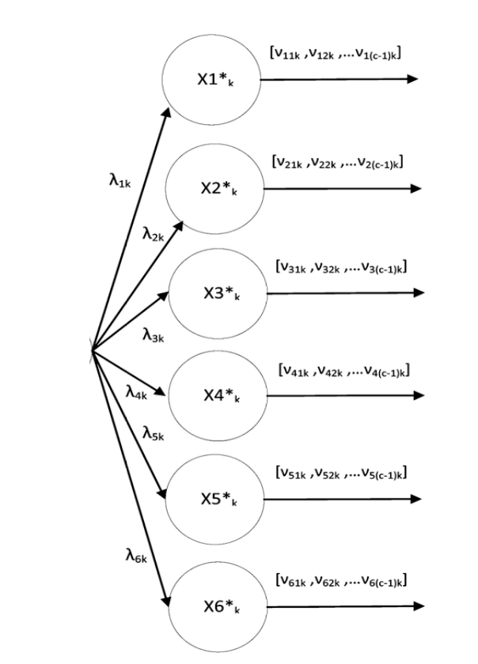

- k denotes group membership
- c is the number of categories in each item
- $\upsilon$ denotes the thresholds
- Factor loadings ($\lambda$) are probit or logit coefficients

See Kim and Yoon (2011) and Svetina, Rutkowski, and Rutkowski (2020)

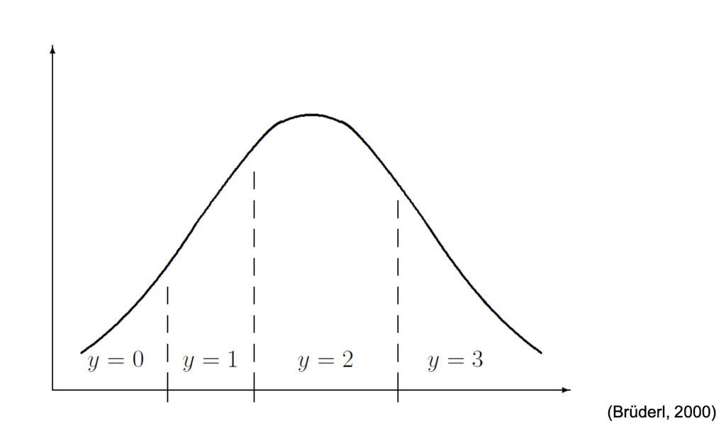

## CFA - Tradition/Conformity

First, we test the model for the entire population again.

- Factor loadings are now probit coefficients
- Intercepts are fixed to 0 for identifcation
- Scales y* are SD of the latent response

### Model for whole population

```r
tradition_conformity_fit_cat <- cfa(
  model = "
  TraditionConformity =~ NA*imptrad + ipfrule + ipbhprp
  TraditionConformity ~~ 1*TraditionConformity
  ",
  data = ESS07,
  estimator = "WLSM",
  # fiml is not available with categorical data
  # missing = "fiml.x",
  ordered=c("imptrad","ipfrule","ipbhprp")
)
```

```r
summary(
  object = tradition_conformity_fit_cat,
  fit.measures = T,
  standardized = T
  # rsquare = T
)
```

```
lavaan 0.6.14 ended normally after 1 iteration

  Estimator                                       DWLS
  Optimization method                           NLMINB
  Number of model parameters                        18

  Number of observations                          5844

Model Test User Model:
                                              Standard      Scaled
  Test Statistic                                 0.000       0.000
  Degrees of freedom                                 0           0

Model Test Baseline Model:

  Test statistic                              3760.691    3760.691
  Degrees of freedom                                 3           3
  P-value                                        0.000       0.000
  Scaling correction factor                                  1.000

User Model versus Baseline Model:

  Comparative Fit Index (CFI)                    1.000       1.000
  Tucker-Lewis Index (TLI)                       1.000       1.000

  Robust Comparative Fit Index (CFI)                         1.000
  Robust Tucker-Lewis Index (TLI)                            1.000

Root Mean Square Error of Approximation:

  RMSEA                                          0.000          NA
  90 Percent confidence interval - lower         0.000          NA
  90 Percent confidence interval - upper         0.000          NA
  P-value H_0: RMSEA <= 0.050                       NA          NA
  P-value H_0: RMSEA >= 0.080                       NA          NA

  Robust RMSEA                                               0.000
  90 Percent confidence interval - lower                     0.000
  90 Percent confidence interval - upper                     0.000
  P-value H_0: Robust RMSEA <= 0.050                            NA
```

[output cut: 41 more lines]

```
    ipbhprp|t4       -0.019    0.016   -1.151    0.250   -0.019   -0.019
    ipbhprp|t5        1.009    0.020   50.894    0.000    1.009    1.009

Variances:
                   Estimate  Std.Err  z-value  P(>|z|)   Std.lv  Std.all
    TraditnCnfrmty    1.000                               1.000    1.000
   .imptrad           0.727                               0.727    0.727
   .ipfrule           0.618                               0.618    0.618
   .ipbhprp           0.516                               0.516    0.516

Scales y*:
                   Estimate  Std.Err  z-value  P(>|z|)   Std.lv  Std.all
    imptrad           1.000                               1.000    1.000
    ipfrule           1.000                               1.000    1.000
    ipbhprp           1.000                               1.000    1.000
```

The model has just been identified and therefore has a perfect fit with the data. In addition, the factor loadings are sufficient.

### Measurement for each group

Now we want to test the model in all subgroups.

```r
ESS07_countries <- ESS07 %>%
  split(as.factor(.$country))
```

```r
tradition_conformity_fit_cat_countries <- ESS07_countries %>%
  map(~ cfa(
    model = "
    TraditionConformity =~ NA*imptrad + ipfrule + ipbhprp
    TraditionConformity ~~ 1*TraditionConformity
    ",
    data = .,
    estimator = "WLSM",
    # fiml is not available with categorical data
    # missing = "fiml.x",
    ordered=c("imptrad","ipfrule","ipbhprp")
  ))
```

```r
tradition_conformity_fit_cat_countries %>%
  map(~ summary(
    object = .,
    fit.measures = T,
    standardized = T
    # rsquare = T
  ))
```

```
$CZ
lavaan 0.6.14 ended normally after 1 iteration

  Estimator                                       DWLS
  Optimization method                           NLMINB
  Number of model parameters                        18

  Number of observations                          1393

Model Test User Model:
                                              Standard      Scaled
  Test Statistic                                 0.000       0.000
  Degrees of freedom                                 0           0

Model Test Baseline Model:

  Test statistic                               992.536     992.536
  Degrees of freedom                                 3           3
  P-value                                        0.000       0.000
  Scaling correction factor                                  1.000

User Model versus Baseline Model:

  Comparative Fit Index (CFI)                    1.000       1.000
  Tucker-Lewis Index (TLI)                       1.000       1.000

  Robust Comparative Fit Index (CFI)                         1.000
  Robust Tucker-Lewis Index (TLI)                            1.000

Root Mean Square Error of Approximation:

  RMSEA                                          0.000          NA
  90 Percent confidence interval - lower         0.000          NA
  90 Percent confidence interval - upper         0.000          NA
  P-value H_0: RMSEA <= 0.050                       NA          NA
  P-value H_0: RMSEA >= 0.080                       NA          NA

  Robust RMSEA                                               0.000
  90 Percent confidence interval - lower                     0.000
  90 Percent confidence interval - upper                     0.000
```

[output cut: 240 more lines]

```
    ipbhprp|t4       -0.171    0.030   -5.732    0.000   -0.171   -0.171
    ipbhprp|t5        0.906    0.035   26.175    0.000    0.906    0.906

Variances:
                   Estimate  Std.Err  z-value  P(>|z|)   Std.lv  Std.all
    TraditnCnfrmty    1.000                               1.000    1.000
   .imptrad           0.723                               0.723    0.723
   .ipfrule           0.644                               0.644    0.644
   .ipbhprp           0.503                               0.503    0.503

Scales y*:
                   Estimate  Std.Err  z-value  P(>|z|)   Std.lv  Std.all
    imptrad           1.000                               1.000    1.000
    ipfrule           1.000                               1.000    1.000
    ipbhprp           1.000                               1.000    1.000
```

### Configural model

Now we want to test the configural measurement model.

```r
tradition_conformity_fit_cat_config <- cfa(
  model = "
  TraditionConformity =~ NA*imptrad + ipfrule + ipbhprp
  TraditionConformity ~~ 1*TraditionConformity
  ",
  data = ESS07,
  estimator = "WLSM",
  group = "country",
  # fiml is not available with categorical data
  # missing = "fiml.x",
  ordered=c("imptrad","ipfrule","ipbhprp")
)
```

```r
summary(
  object = tradition_conformity_fit_cat_config,
  fit.measures = T,
  standardized = T
  # rsquare = T
)
```

```
lavaan 0.6.14 ended normally after 1 iteration

  Estimator                                       DWLS
  Optimization method                           NLMINB
  Number of model parameters                        54

  Number of observations per group:
    CZ                                            1393
    DE                                            2671
    GB                                            1780

Model Test User Model:
                                              Standard      Scaled
  Test Statistic                                 0.000       0.000
  Degrees of freedom                                 0           0
  Test statistic for each group:
    CZ                                           0.000       0.000
    DE                                           0.000       0.000
    GB                                           0.000       0.000

Model Test Baseline Model:

  Test statistic                              3485.867    3485.867
  Degrees of freedom                                 9           9
  P-value                                        0.000       0.000
  Scaling correction factor                                  1.000

User Model versus Baseline Model:

  Comparative Fit Index (CFI)                    1.000       1.000
  Tucker-Lewis Index (TLI)                       1.000       1.000

  Robust Comparative Fit Index (CFI)                         1.000
  Robust Tucker-Lewis Index (TLI)                            1.000

Root Mean Square Error of Approximation:

  RMSEA                                          0.000          NA
  90 Percent confidence interval - lower         0.000          NA
  90 Percent confidence interval - upper         0.000          NA
```

[output cut: 147 more lines]

```
    ipbhprp|t4       -0.171    0.030   -5.732    0.000   -0.171   -0.171
    ipbhprp|t5        0.906    0.035   26.176    0.000    0.906    0.906

Variances:
                   Estimate  Std.Err  z-value  P(>|z|)   Std.lv  Std.all
    TraditnCnfrmty    1.000                               1.000    1.000
   .imptrad           0.723                               0.723    0.723
   .ipfrule           0.644                               0.644    0.644
   .ipbhprp           0.503                               0.503    0.503

Scales y*:
                   Estimate  Std.Err  z-value  P(>|z|)   Std.lv  Std.all
    imptrad           1.000                               1.000    1.000
    ipfrule           1.000                               1.000    1.000
    ipbhprp           1.000                               1.000    1.000
```

### Metric model

```r
tradition_conformity_fit_cat_metric <- cfa(
  model = "
  group: [CZ]
  TraditionConformity =~ NA*imptrad + a*imptrad + b*ipfrule + c*ipbhprp
  TraditionConformity ~~ 1*TraditionConformity

  group: [DE]
  TraditionConformity =~ NA*imptrad + a*imptrad + b*ipfrule + c*ipbhprp
  TraditionConformity ~~ NA*TraditionConformity

  group: [GB]
  TraditionConformity =~ NA*imptrad + a*imptrad + b*ipfrule + c*ipbhprp
  TraditionConformity ~~ NA*TraditionConformity
  ",
  data = ESS07,
  estimator = "WLSM",
  group = "country",
  # fiml is not available with categorical data
  # missing = "fiml.x",
  ordered=c("imptrad","ipfrule","ipbhprp")
)
```

```r
summary(
  object = tradition_conformity_fit_cat_metric,
  fit.measures = T,
  standardized = T
  # rsquare = T
)
```

```
lavaan 0.6.14 ended normally after 34 iterations

  Estimator                                       DWLS
  Optimization method                           NLMINB
  Number of model parameters                        56
  Number of equality constraints                     6

  Number of observations per group:
    CZ                                            1393
    DE                                            2671
    GB                                            1780

Model Test User Model:
                                              Standard      Scaled
  Test Statistic                                 1.305       1.838
  Degrees of freedom                                 4           4
  P-value (Chi-square)                           0.861       0.765
  Scaling correction factor                                  0.710
    Satorra-Bentler correction
  Test statistic for each group:
    CZ                                           0.240       0.338
    DE                                           0.786       1.108
    GB                                           0.278       0.392

Model Test Baseline Model:

  Test statistic                              3485.867    3485.867
  Degrees of freedom                                 9           9
  P-value                                        0.000       0.000
  Scaling correction factor                                  1.000

User Model versus Baseline Model:

  Comparative Fit Index (CFI)                    1.000       1.000
  Tucker-Lewis Index (TLI)                       1.002       1.001

  Robust Comparative Fit Index (CFI)                         1.000
  Robust Tucker-Lewis Index (TLI)                            1.002

Root Mean Square Error of Approximation:
```

[output cut: 151 more lines]

```
    ipbhprp|t4       -0.171    0.030   -5.732    0.000   -0.171   -0.171
    ipbhprp|t5        0.906    0.035   26.176    0.000    0.906    0.906

Variances:
                   Estimate  Std.Err  z-value  P(>|z|)   Std.lv  Std.all
    TraditnCnfrmty    0.969    0.053   18.179    0.000    1.000    1.000
   .imptrad           0.733                               0.733    0.733
   .ipfrule           0.632                               0.632    0.632
   .ipbhprp           0.505                               0.505    0.505

Scales y*:
                   Estimate  Std.Err  z-value  P(>|z|)   Std.lv  Std.all
    imptrad           1.000                               1.000    1.000
    ipfrule           1.000                               1.000    1.000
    ipbhprp           1.000                               1.000    1.000
```

### Scalar model

**Here it is important to equate the thresholds instead of intercepts!**

```r
tradition_conformity_fit_cat_scalar <- cfa(
  model = "
    group: [CZ]
    TraditionConformity =~ NA*imptrad + a*imptrad + b*ipfrule + c*ipbhprp
    imptrad | d1*t1 + d2*t2 + d3*t3 + d4*t4 + d5*t5
    ipfrule | e1*t1 + e2*t2 + e3*t3 + e4*t4 + e5*t5
    ipbhprp | f1*t1 + f2*t2 + f3*t3 + f4*t4 + f5*t5
    TraditionConformity ~ 0*1
    TraditionConformity ~~ 1*TraditionConformity

    group: [DE]
    TraditionConformity =~ NA*imptrad + a*imptrad + b*ipfrule + c*ipbhprp
    imptrad | d1*t1 + d2*t2 + d3*t3 + d4*t4 + d5*t5
    imptrad ~*~ NA*imptrad
    ipfrule | e1*t1 + e2*t2 + e3*t3 + e4*t4 + e5*t5
    ipfrule ~*~ NA*ipfrule
    ipbhprp | f1*t1 + f2*t2 + f3*t3 + f4*t4 + f5*t5
    ipbhprp ~*~ NA*ipbhprp
    TraditionConformity ~ NA*1
    TraditionConformity ~~ NA*TraditionConformity

    group: [GB]
    TraditionConformity =~ NA*imptrad + a*imptrad + b*ipfrule + c*ipbhprp
    imptrad | d1*t1 + d2*t2 + d3*t3 + d4*t4 + d5*t5
    imptrad ~*~ NA*imptrad
    ipfrule | e1*t1 + e2*t2 + e3*t3 + e4*t4 + e5*t5
    ipfrule ~*~ NA*ipfrule
    ipbhprp | f1*t1 + f2*t2 + f3*t3 + f4*t4 + f5*t5
    ipbhprp ~*~ NA*ipbhprp
    TraditionConformity ~ NA*1
    TraditionConformity ~~ NA*TraditionConformity
  ",
  data = ESS07,
  estimator = "WLSM",
  group = "country",
  # fiml is not available with categorical data
  # missing = "fiml.x",
  ordered=c("imptrad","ipfrule","ipbhprp")
)
```

```r
summary(
  object = tradition_conformity_fit_cat_scalar,
  fit.measures = T,
  standardized = T
  # rsquare = T
)
```

```
lavaan 0.6.14 ended normally after 60 iterations

  Estimator                                       DWLS
  Optimization method                           NLMINB
  Number of model parameters                        64
  Number of equality constraints                    36

  Number of observations per group:
    CZ                                            1393
    DE                                            2671
    GB                                            1780

Model Test User Model:
                                              Standard      Scaled
  Test Statistic                               287.707     418.178
  Degrees of freedom                                26          26
  P-value (Chi-square)                           0.000       0.000
  Scaling correction factor                                  0.688
    Satorra-Bentler correction
  Test statistic for each group:
    CZ                                         174.188     253.179
    DE                                          23.949      34.810
    GB                                          89.570     130.189

Model Test Baseline Model:

  Test statistic                              3485.867    3485.867
  Degrees of freedom                                 9           9
  P-value                                        0.000       0.000
  Scaling correction factor                                  1.000

User Model versus Baseline Model:

  Comparative Fit Index (CFI)                    0.925       0.887
  Tucker-Lewis Index (TLI)                       0.974       0.961

  Robust Comparative Fit Index (CFI)                            NA
  Robust Tucker-Lewis Index (TLI)                               NA

Root Mean Square Error of Approximation:
```

[output cut: 151 more lines]

```
    ipbhprp|4 (f4)   -0.314    0.025  -12.556    0.000   -0.314   -0.318
    ipbhprp|5 (f5)    0.705    0.033   21.500    0.000    0.705    0.715

Variances:
                   Estimate  Std.Err  z-value  P(>|z|)   Std.lv  Std.all
    TraditnCnfrmty    1.226    0.105   11.681    0.000    1.000    1.000
   .imptrad           0.901                               0.901    0.762
   .ipfrule           0.880                               0.880    0.539
   .ipbhprp           0.559                               0.559    0.575

Scales y*:
                   Estimate  Std.Err  z-value  P(>|z|)   Std.lv  Std.all
    imptrad           0.920    0.028   33.210    0.000    0.920    1.000
    ipfrule           0.782    0.023   33.647    0.000    0.782    1.000
    ipbhprp           1.014    0.031   32.683    0.000    1.014    1.000
```

### Comparing fit statistics

```r
compFit.tradition_conformity_cat <- compareFit(
  scalar = tradition_conformity_fit_cat_scalar,
  metric = tradition_conformity_fit_cat_metric,
  config = tradition_conformity_fit_cat_config,
  nested =T,
  indices = T,
  argsLRT=list(asymptotic=T, method="satorra.bentler.2010")
)
```

```r
summary(
  object = compFit.tradition_conformity_cat,
  fit.measures = c("chisq.scaled", "df.scaled", "pvalue.scaled",
                   "rmsea.scaled", "cfi.scaled", "tli.scaled",
                   "srmr")
  )
```

```
################### Nested Model Comparison #########################

Scaled Chi-Squared Difference Test (method = "satorra.bentler.2010")

lavaan NOTE:
    The "Chisq" column contains standard test statistics, not the
    robust test that should be reported per model. A robust difference
    test is a function of two standard (not robust) statistics.

       Df AIC BIC    Chisq Chisq diff Df diff Pr(>Chisq)
config  0           0.0000
metric  4           1.3045                  4
scalar 26         287.7072     419.84      22  < 2.2e-16 ***
---
Signif. codes:  0 '***' 0.001 '**' 0.01 '*' 0.05 '.' 0.1 ' ' 1

####################### Model Fit Indices ###########################
       chisq.scaled df.scaled pvalue.scaled rmsea.scaled cfi.scaled tli.scaled
config        .000†                      NA          NA      1.000†     1.000
metric       1.838          4          .765        .000†     1.000†     1.001†
scalar     418.178         26          .000        .088       .887       .961
        srmr
config .000†
metric .005
scalar .027

################## Differences in Fit Indices #######################
                df.scaled rmsea.scaled cfi.scaled tli.scaled  srmr
metric - config         4           NA      0.000      0.001 0.005
scalar - metric        22        0.088     -0.113     -0.040 0.022
```

### Partial measurement invariance

```r
tradition_conformity_fit_cat_scalar %>%
  lavTestScore() %>%
  pluck("uni") %>%
  arrange(desc(X2)) %>%
  filter(X2 > 5) %>%
  # optional for better display
  export_table(table_width = 1, digits = 2)
```

```
lhs   | op |   rhs |    X2 | df |  p.value
------------------------------------------
.p17. | == | .p77. | 34.57 |  1 | 4.11e-09
.p11. | == | .p70. | 30.30 |  1 | 3.70e-08
.p18. | == | .p78. | 18.93 |  1 | 1.36e-05
.p3.  | == | .p61. | 13.61 |  1 | 2.24e-04
.p9.  | == | .p68. | 13.23 |  1 | 2.75e-04
.p4.  | == | .p62. |  9.55 |  1 | 2.00e-03
.p1.  | == | .p30. |  9.09 |  1 | 2.57e-03
.p6.  | == | .p35. |  8.90 |  1 | 2.85e-03
.p10. | == | .p69. |  8.78 |  1 | 3.04e-03
.p10. | == | .p40. |  7.65 |  1 | 5.69e-03
.p12. | == | .p71. |  6.89 |  1 | 8.68e-03
.p13. | == | .p43. |  6.75 |  1 | 9.37e-03
.p14. | == | .p74. |  6.58 |  1 |     0.01
.p5.  | == | .p63. |  6.40 |  1 |     0.01
.p6.  | == | .p64. |  5.50 |  1 |     0.02
.p4.  | == | .p33. |  5.38 |  1 |     0.02
```

```r
tradition_conformity_fit_cat_scalar %>%
  parTable() %>%
  select(lhs, op, rhs, group, label, plabel, est, se) %>%
  filter(plabel == ".p17.") %>%
  # optional for better display
  export_table(table_width = 1, digits = 2)
```

```
lhs     | op | rhs | group | label | plabel |   est |   se
----------------------------------------------------------
ipbhprp |  | |  t4 |  [CZ] |    f4 |  .p17. | -0.31 | 0.02
```

```r
tradition_conformity_fit_cat_scalar_partial <- cfa(
  model = "
      group: [CZ]
    TraditionConformity =~ NA*imptrad + a*imptrad + b*ipfrule + c*ipbhprp
    imptrad | d1*t1 + d2*t2 + d3*t3 + d4*t4 + d5*t5
    ipfrule | e1*t1 + e2*t2 + e3*t3 + e4*t4 + e5*t5
    ipbhprp | NA*t1 + NA*t2 + NA*t3 + NA*t4 + NA*t5
    TraditionConformity ~ 0*1
    TraditionConformity ~~ 1*TraditionConformity

    group: [DE]
    TraditionConformity =~ NA*imptrad + a*imptrad + b*ipfrule + c*ipbhprp
    imptrad | d1*t1 + d2*t2 + d3*t3 + d4*t4 + d5*t5
    imptrad ~*~ NA*imptrad
    ipfrule | e1*t1 + e2*t2 + e3*t3 + e4*t4 + e5*t5
    ipfrule ~*~ NA*ipfrule
    ipbhprp | NA*t1 + NA*t2 + NA*t3 + NA*t4 + NA*t5
    ipbhprp ~*~ NA*ipbhprp
    TraditionConformity ~ NA*1
    TraditionConformity ~~ NA*TraditionConformity

    group: [GB]
    TraditionConformity =~ NA*imptrad + a*imptrad + b*ipfrule + c*ipbhprp
    imptrad | d1*t1 + d2*t2 + d3*t3 + d4*t4 + d5*t5
    imptrad ~*~ NA*imptrad
    ipfrule | e1*t1 + e2*t2 + e3*t3 + e4*t4 + e5*t5
    ipfrule ~*~ NA*ipfrule
    ipbhprp | NA*t1 + NA*t2 + NA*t3 + NA*t4 + NA*t5
    ipbhprp ~*~ NA*ipbhprp
    TraditionConformity ~ NA*1
    TraditionConformity ~~ NA*TraditionConformity
  ",
  data = ESS07,
  estimator = "WLSM",
  group = "country",
  # fiml is not available with categorical data
  # missing = "fiml.x",
  ordered=c("imptrad","ipfrule","ipbhprp")
)
```

```r
summary(
  object = tradition_conformity_fit_cat_scalar_partial,
  fit.measures = T,
  standardized = T
  # rsquare = T
)
```

```
lavaan 0.6.14 ended normally after 82 iterations

  Estimator                                       DWLS
  Optimization method                           NLMINB
  Number of model parameters                        64
  Number of equality constraints                    26

  Number of observations per group:
    CZ                                            1393
    DE                                            2671
    GB                                            1780

Model Test User Model:
                                              Standard      Scaled
  Test Statistic                               158.925     237.047
  Degrees of freedom                                16          16
  P-value (Chi-square)                           0.000       0.000
  Scaling correction factor                                  0.670
    Satorra-Bentler correction
  Test statistic for each group:
    CZ                                         101.584     151.518
    DE                                          16.070      23.969
    GB                                          41.272      61.559

Model Test Baseline Model:

  Test statistic                              3485.867    3485.867
  Degrees of freedom                                 9           9
  P-value                                        0.000       0.000
  Scaling correction factor                                  1.000

User Model versus Baseline Model:

  Comparative Fit Index (CFI)                    0.959       0.936
  Tucker-Lewis Index (TLI)                       0.977       0.964

  Robust Comparative Fit Index (CFI)                            NA
  Robust Tucker-Lewis Index (TLI)                               NA

Root Mean Square Error of Approximation:
```

[output cut: 151 more lines]

```
    ipbhprp|4        -0.634    0.061  -10.389    0.000   -0.634   -0.582
    ipbhprp|5         0.539    0.089    6.079    0.000    0.539    0.495

Variances:
                   Estimate  Std.Err  z-value  P(>|z|)   Std.lv  Std.all
    TraditnCnfrmty    1.282    0.152    8.421    0.000    1.000    1.000
   .imptrad           0.852                               0.852    0.763
   .ipfrule           0.925                               0.925    0.582
   .ipbhprp           0.626                               0.626    0.528

Scales y*:
                   Estimate  Std.Err  z-value  P(>|z|)   Std.lv  Std.all
    imptrad           0.946    0.029   32.615    0.000    0.946    1.000
    ipfrule           0.794    0.023   33.933    0.000    0.794    1.000
    ipbhprp           0.918    0.087   10.599    0.000    0.918    1.000
```

```r
compFit.tradition_conformity_cat2 <- compareFit(
  scalar = tradition_conformity_fit_cat_scalar_partial,
  metric = tradition_conformity_fit_cat_metric,
  config = tradition_conformity_fit_cat_config,
  nested =T,
  indices = T,
  argsLRT=list(asymptotic=T, method="satorra.bentler.2010")
)
```

```r
summary(
  object = compFit.tradition_conformity_cat2,
  fit.measures = c("chisq.scaled", "df.scaled", "pvalue.scaled",
                   "rmsea.scaled", "cfi.scaled", "tli.scaled",
                   "srmr")
  )
```

```
################### Nested Model Comparison #########################

Scaled Chi-Squared Difference Test (method = "satorra.bentler.2010")

lavaan NOTE:
    The "Chisq" column contains standard test statistics, not the
    robust test that should be reported per model. A robust difference
    test is a function of two standard (not robust) statistics.

       Df AIC BIC    Chisq Chisq diff Df diff Pr(>Chisq)
config  0           0.0000
metric  4           1.3045                  4
scalar 16         158.9253     242.08      12  < 2.2e-16 ***
---
Signif. codes:  0 '***' 0.001 '**' 0.01 '*' 0.05 '.' 0.1 ' ' 1

####################### Model Fit Indices ###########################
       chisq.scaled df.scaled pvalue.scaled rmsea.scaled cfi.scaled tli.scaled
config        .000†                      NA          NA      1.000†     1.000
metric       1.838          4          .765        .000†     1.000†     1.001†
scalar     237.047         16          .000        .084       .936       .964
        srmr
config .000†
metric .005
scalar .016

################## Differences in Fit Indices #######################
                df.scaled rmsea.scaled cfi.scaled tli.scaled  srmr
metric - config         4           NA      0.000      0.001 0.005
scalar - metric        12        0.084     -0.064     -0.037 0.011
```

## CFA - Perceived Threat

### Model for whole population

```r
perceived_threat_fit_cat <- cfa(
  model = "
    PerceivedThreat =~ imbgeco + imueclt + imtcjob + rlgueim
    imueclt ~~ rlgueim
  ",
  data = ESS07,
  estimator = "WLSM",
  # fiml is not available with categorical data
  # missing = "fiml.x",
  ordered=c("imbgeco","imueclt","imtcjob","rlgueim")
)
```

```r
summary(
  object = perceived_threat_fit_cat,
  fit.measures = T,
  standardized = T
  # rsquare = T
)
```

```
lavaan 0.6.14 ended normally after 17 iterations

  Estimator                                       DWLS
  Optimization method                           NLMINB
  Number of model parameters                        45

  Number of observations                          5844

Model Test User Model:
                                              Standard      Scaled
  Test Statistic                                23.634      77.569
  Degrees of freedom                                 1           1
  P-value (Chi-square)                           0.000       0.000
  Scaling correction factor                                  0.305
    Satorra-Bentler correction

Model Test Baseline Model:

  Test statistic                             38065.469   38065.469
  Degrees of freedom                                 6           6
  P-value                                        0.000       0.000
  Scaling correction factor                                  1.000

User Model versus Baseline Model:

  Comparative Fit Index (CFI)                    0.999       0.998
  Tucker-Lewis Index (TLI)                       0.996       0.988

  Robust Comparative Fit Index (CFI)                         0.994
  Robust Tucker-Lewis Index (TLI)                            0.961

Root Mean Square Error of Approximation:

  RMSEA                                          0.062       0.114
  90 Percent confidence interval - lower         0.042       0.000
  90 Percent confidence interval - upper         0.085       0.000
  P-value H_0: RMSEA <= 0.050                    0.149       0.002
  P-value H_0: RMSEA >= 0.080                    0.105       0.942

  Robust RMSEA                                               0.102
```

[output cut: 78 more lines]

```

Variances:
                   Estimate  Std.Err  z-value  P(>|z|)   Std.lv  Std.all
   .imbgeco           0.267                               0.267    0.267
   .imueclt           0.363                               0.363    0.363
   .imtcjob           0.491                               0.491    0.491
   .rlgueim           0.681                               0.681    0.681
    PerceivedThret    0.733    0.009   78.944    0.000    1.000    1.000

Scales y*:
                   Estimate  Std.Err  z-value  P(>|z|)   Std.lv  Std.all
    imbgeco           1.000                               1.000    1.000
    imueclt           1.000                               1.000    1.000
    imtcjob           1.000                               1.000    1.000
    rlgueim           1.000                               1.000    1.000
```

### Measurement for each group

```r
perceived_threat_fit_cat_countries <- ESS07_countries %>%
  map(~ cfa(
    model = "
    PerceivedThreat =~ imbgeco + imueclt + imtcjob + rlgueim
    imueclt ~~ rlgueim
    ",
    data = .,
    estimator = "WLSM",
    # fiml is not available with categorical data
    # missing = "fiml.x",
    ordered=c("imbgeco","imueclt","imtcjob","rlgueim")
  ))
```

```r
perceived_threat_fit_cat_countries %>%
  map(~ summary(
    object = .,
    fit.measures = T,
    standardized = T
    # rsquare = T
  ))
```

```
$CZ
lavaan 0.6.14 ended normally after 16 iterations

  Estimator                                       DWLS
  Optimization method                           NLMINB
  Number of model parameters                        45

  Number of observations                          1393

Model Test User Model:
                                              Standard      Scaled
  Test Statistic                                 7.531      19.529
  Degrees of freedom                                 1           1
  P-value (Chi-square)                           0.006       0.000
  Scaling correction factor                                  0.386
    Satorra-Bentler correction

Model Test Baseline Model:

  Test statistic                              5280.744    5280.744
  Degrees of freedom                                 6           6
  P-value                                        0.000       0.000
  Scaling correction factor                                  1.000

User Model versus Baseline Model:

  Comparative Fit Index (CFI)                    0.999       0.996
  Tucker-Lewis Index (TLI)                       0.993       0.979

  Robust Comparative Fit Index (CFI)                         0.992
  Robust Tucker-Lewis Index (TLI)                            0.951

Root Mean Square Error of Approximation:

  RMSEA                                          0.068       0.115
  90 Percent confidence interval - lower         0.029       0.000
  90 Percent confidence interval - upper         0.118       0.000
  P-value H_0: RMSEA <= 0.050                    0.190       0.039
  P-value H_0: RMSEA >= 0.080                    0.405       0.849

```

[output cut: 351 more lines]

```

Variances:
                   Estimate  Std.Err  z-value  P(>|z|)   Std.lv  Std.all
   .imbgeco           0.290                               0.290    0.290
   .imueclt           0.337                               0.337    0.337
   .imtcjob           0.543                               0.543    0.543
   .rlgueim           0.655                               0.655    0.655
    PerceivedThret    0.710    0.017   41.878    0.000    1.000    1.000

Scales y*:
                   Estimate  Std.Err  z-value  P(>|z|)   Std.lv  Std.all
    imbgeco           1.000                               1.000    1.000
    imueclt           1.000                               1.000    1.000
    imtcjob           1.000                               1.000    1.000
    rlgueim           1.000                               1.000    1.000
```

### Configural model

```r
perceived_threat_fit_cat_config <- cfa(
  model = "
    PerceivedThreat =~ imbgeco + imueclt + imtcjob + rlgueim
    imueclt ~~ rlgueim
  ",
  data = ESS07,
  estimator = "WLSM",
  group = "country",
  # fiml is not available with categorical data
  # missing = "fiml.x",
  ordered=c("imbgeco","imueclt","imtcjob","rlgueim")
)
```

```r
summary(
  object = perceived_threat_fit_cat_config,
  fit.measures = T,
  standardized = T
  # rsquare = T
)
```

```
lavaan 0.6.14 ended normally after 33 iterations

  Estimator                                       DWLS
  Optimization method                           NLMINB
  Number of model parameters                       135

  Number of observations per group:
    CZ                                            1393
    DE                                            2671
    GB                                            1780

Model Test User Model:
                                              Standard      Scaled
  Test Statistic                                29.363      80.691
  Degrees of freedom                                 3           3
  P-value (Chi-square)                           0.000       0.000
  Scaling correction factor                                  0.364
    Satorra-Bentler correction
  Test statistic for each group:
    CZ                                           7.531      20.695
    DE                                          14.253      39.167
    GB                                           7.580      20.830

Model Test Baseline Model:

  Test statistic                             27100.216   27100.216
  Degrees of freedom                                18          18
  P-value                                        0.000       0.000
  Scaling correction factor                                  1.000

User Model versus Baseline Model:

  Comparative Fit Index (CFI)                    0.999       0.997
  Tucker-Lewis Index (TLI)                       0.994       0.983

  Robust Comparative Fit Index (CFI)                         0.991
  Robust Tucker-Lewis Index (TLI)                            0.947

Root Mean Square Error of Approximation:

```

[output cut: 252 more lines]

```

Variances:
                   Estimate  Std.Err  z-value  P(>|z|)   Std.lv  Std.all
   .imbgeco           0.290                               0.290    0.290
   .imueclt           0.337                               0.337    0.337
   .imtcjob           0.543                               0.543    0.543
   .rlgueim           0.655                               0.655    0.655
    PerceivedThret    0.710    0.017   41.879    0.000    1.000    1.000

Scales y*:
                   Estimate  Std.Err  z-value  P(>|z|)   Std.lv  Std.all
    imbgeco           1.000                               1.000    1.000
    imueclt           1.000                               1.000    1.000
    imtcjob           1.000                               1.000    1.000
    rlgueim           1.000                               1.000    1.000
```

### Metric model

```r
perceived_threat_fit_cat_metric <- cfa(
  model = "
    PerceivedThreat =~ imbgeco + imueclt + imtcjob + rlgueim
    imueclt ~~ rlgueim
  ",
  data = ESS07,
  estimator = "WLSM",
  group = "country",
  group.equal = c("loadings"),
  # fiml is not available with categorical data
  # missing = "fiml.x",
  ordered=c("imbgeco","imueclt","imtcjob","rlgueim")
)
```

```r
summary(
  object = perceived_threat_fit_cat_metric,
  fit.measures = T,
  standardized = T
  # rsquare = T
)
```

```
lavaan 0.6.14 ended normally after 31 iterations

  Estimator                                       DWLS
  Optimization method                           NLMINB
  Number of model parameters                       135
  Number of equality constraints                     6

  Number of observations per group:
    CZ                                            1393
    DE                                            2671
    GB                                            1780

Model Test User Model:
                                              Standard      Scaled
  Test Statistic                                50.594      84.735
  Degrees of freedom                                 9           9
  P-value (Chi-square)                           0.000       0.000
  Scaling correction factor                                  0.597
    Satorra-Bentler correction
  Test statistic for each group:
    CZ                                          14.272      23.902
    DE                                          21.297      35.669
    GB                                          15.025      25.164

Model Test Baseline Model:

  Test statistic                             27100.216   27100.216
  Degrees of freedom                                18          18
  P-value                                        0.000       0.000
  Scaling correction factor                                  1.000

User Model versus Baseline Model:

  Comparative Fit Index (CFI)                    0.998       0.997
  Tucker-Lewis Index (TLI)                       0.997       0.994

  Robust Comparative Fit Index (CFI)                         0.989
  Robust Tucker-Lewis Index (TLI)                            0.977

Root Mean Square Error of Approximation:
```

[output cut: 253 more lines]

```

Variances:
                   Estimate  Std.Err  z-value  P(>|z|)   Std.lv  Std.all
   .imbgeco           0.245                               0.245    0.245
   .imueclt           0.373                               0.373    0.373
   .imtcjob           0.531                               0.531    0.531
   .rlgueim           0.702                               0.702    0.702
    PerceivedThret    0.755    0.015   49.010    0.000    1.000    1.000

Scales y*:
                   Estimate  Std.Err  z-value  P(>|z|)   Std.lv  Std.all
    imbgeco           1.000                               1.000    1.000
    imueclt           1.000                               1.000    1.000
    imtcjob           1.000                               1.000    1.000
    rlgueim           1.000                               1.000    1.000
```

### Scalar model

```r
perceived_threat_fit_cat_scalar <- cfa(
  model = "
    PerceivedThreat =~ imbgeco + imueclt + imtcjob + rlgueim
    imueclt ~~ rlgueim
  ",
  data = ESS07,
  estimator = "WLSM",
  group = "country",
  group.equal = c("loadings", "thresholds"),
  # fiml is not available with categorical data
  # missing = "fiml.x",
  ordered=c("imbgeco","imueclt","imtcjob","rlgueim")
)
```

```r
summary(
  object = perceived_threat_fit_cat_scalar,
  fit.measures = T,
  standardized = T
  # rsquare = T
)
```

```
lavaan 0.6.14 ended normally after 74 iterations

  Estimator                                       DWLS
  Optimization method                           NLMINB
  Number of model parameters                       145
  Number of equality constraints                    86

  Number of observations per group:
    CZ                                            1393
    DE                                            2671
    GB                                            1780

Model Test User Model:
                                              Standard      Scaled
  Test Statistic                               532.351     881.989
  Degrees of freedom                                79          79
  P-value (Chi-square)                           0.000       0.000
  Scaling correction factor                                  0.604
    Satorra-Bentler correction
  Test statistic for each group:
    CZ                                         265.168     439.326
    DE                                         144.932     240.120
    GB                                         122.251     202.543

Model Test Baseline Model:

  Test statistic                             27100.216   27100.216
  Degrees of freedom                                18          18
  P-value                                        0.000       0.000
  Scaling correction factor                                  1.000

User Model versus Baseline Model:

  Comparative Fit Index (CFI)                    0.983       0.970
  Tucker-Lewis Index (TLI)                       0.996       0.993

  Robust Comparative Fit Index (CFI)                            NA
  Robust Tucker-Lewis Index (TLI)                               NA

Root Mean Square Error of Approximation:
```

[output cut: 253 more lines]

```

Variances:
                   Estimate  Std.Err  z-value  P(>|z|)   Std.lv  Std.all
   .imbgeco           0.445                               0.445    0.293
   .imueclt           0.708                               0.708    0.377
   .imtcjob           0.616                               0.616    0.474
   .rlgueim           0.899                               0.899    0.696
    PerceivedThret    1.076    0.066   16.395    0.000    1.000    1.000

Scales y*:
                   Estimate  Std.Err  z-value  P(>|z|)   Std.lv  Std.all
    imbgeco           0.811    0.022   37.695    0.000    0.811    1.000
    imueclt           0.729    0.019   37.746    0.000    0.729    1.000
    imtcjob           0.877    0.022   40.411    0.000    0.877    1.000
    rlgueim           0.880    0.022   39.403    0.000    0.880    1.000
```

### Comparing fit statistics

```r
compFit.perceived_threat_cat <- compareFit(
  scalar = perceived_threat_fit_cat_scalar,
  metric = perceived_threat_fit_cat_metric,
  config = perceived_threat_fit_cat_config,
  nested = T,
  indices = T,
  argsLRT=list(asymptotic=T, method="satorra.bentler.2010")
)
```

```r
summary(
  object = compFit.perceived_threat_cat,
  fit.measures = c("chisq.scaled", "df.scaled", "pvalue.scaled",
                   "rmsea.scaled", "cfi.scaled", "tli.scaled",
                   "srmr")
  )
```

```
################### Nested Model Comparison #########################

Scaled Chi-Squared Difference Test (method = "satorra.bentler.2010")

lavaan NOTE:
    The "Chisq" column contains standard test statistics, not the
    robust test that should be reported per model. A robust difference
    test is a function of two standard (not robust) statistics.

       Df AIC BIC   Chisq Chisq diff Df diff Pr(>Chisq)
config  3          29.363
metric  9          50.594      29.76       6  4.362e-05 ***
scalar 79         532.351     800.01      70  < 2.2e-16 ***
---
Signif. codes:  0 '***' 0.001 '**' 0.01 '*' 0.05 '.' 0.1 ' ' 1

####################### Model Fit Indices ###########################
       chisq.scaled df.scaled pvalue.scaled rmsea.scaled cfi.scaled tli.scaled
config      80.691†         3          .000        .115      0.997       .983
metric      84.735          9          .000        .066†     0.997†      .994†
scalar     881.989         79          .000        .072       .970       .993
        srmr
config .016†
metric .020
scalar .025

################## Differences in Fit Indices #######################
                df.scaled rmsea.scaled cfi.scaled tli.scaled  srmr
metric - config         6       -0.050      0.000      0.012 0.004
scalar - metric        70        0.007     -0.027     -0.001 0.005
```

### Partial measurement invariance

```r
perceived_threat_fit_cat_scalar %>%
  lavTestScore() %>%
  pluck("uni") %>%
  arrange(desc(X2)) %>%
  filter(X2 > 5) %>%
  # optional for better display
  export_table(table_width = 1, digits = 2)
```

```
lhs   | op |    rhs |    X2 | df |  p.value
-------------------------------------------
.p31. | == |  .p90. | 37.43 |  1 | 9.50e-10
.p32. | == |  .p91. | 17.21 |  1 | 3.35e-05
.p15. | == |  .p74. | 12.62 |  1 | 3.83e-04
.p31. | == | .p149. | 12.52 |  1 | 4.03e-04
.p43. | == | .p161. | 12.25 |  1 | 4.66e-04
.p19. | == |  .p78. | 11.57 |  1 | 6.71e-04
.p44. | == | .p162. | 11.00 |  1 | 9.09e-04
.p22. | == | .p140. | 10.55 |  1 | 1.16e-03
.p30. | == | .p148. | 10.47 |  1 | 1.22e-03
.p6.  | == |  .p65. |  9.04 |  1 | 2.65e-03
.p11. | == | .p129. |  8.45 |  1 | 3.66e-03
.p7.  | == |  .p66. |  8.42 |  1 | 3.70e-03
.p35. | == |  .p94. |  8.22 |  1 | 4.15e-03
.p41. | == | .p100. |  8.08 |  1 | 4.48e-03
.p14. | == |  .p73. |  7.70 |  1 | 5.52e-03
.p42. | == | .p160. |  7.01 |  1 | 8.11e-03
.p12. | == | .p130. |  6.67 |  1 | 9.81e-03
.p4.  | == | .p122. |  6.29 |  1 |     0.01
.p38. | == | .p156. |  6.28 |  1 |     0.01
.p2.  | == |  .p61. |  6.17 |  1 |     0.01
.p37. | == |  .p96. |  6.05 |  1 |     0.01
.p45. | == | .p104. |  5.94 |  1 |     0.01
.p41. | == | .p159. |  5.73 |  1 |     0.02
.p9.  | == | .p127. |  5.71 |  1 |     0.02
.p12. | == |  .p71. |  5.13 |  1 |     0.02
.p20. | == |  .p79. |  5.03 |  1 |     0.02
```

```r
perceived_threat_fit_cat_scalar %>%
  parTable() %>%
  select(lhs, op, rhs, group, label, plabel, est, se) %>%
  filter(plabel == ".p31.") %>%
  # optional for better display
  export_table(table_width = 1, digits = 2)
```

```
lhs     | op | rhs | group | label | plabel |   est |   se
----------------------------------------------------------
imtcjob |  | |  t6 |     1 | .p31. |  .p31. | -0.13 | 0.02
```

```r
perceived_threat_fit_cat_scalar_partial <- cfa(
  model = "
    PerceivedThreat =~ imbgeco + imueclt + imtcjob + rlgueim
    imueclt ~~ rlgueim
  ",
  data = ESS07,
  estimator = "WLSM",
  group = "country",
  group.equal = c("loadings", "thresholds"),
  group.partial = c("imtcjob|t1","imtcjob|t2","imtcjob|t3",
                    "imtcjob|t4","imtcjob|t5"),
  # fiml is not available with categorical data
  # missing = "fiml.x",
  ordered=c("imbgeco","imueclt","imtcjob","rlgueim")
)
```

```r
summary(
  object = perceived_threat_fit_cat_scalar_partial,
  fit.measures = T,
  standardized = T
  # rsquare = T
)
```

```
lavaan 0.6.14 ended normally after 93 iterations

  Estimator                                       DWLS
  Optimization method                           NLMINB
  Number of model parameters                       145
  Number of equality constraints                    76

  Number of observations per group:
    CZ                                            1393
    DE                                            2671
    GB                                            1780

Model Test User Model:
                                              Standard      Scaled
  Test Statistic                               487.494     842.351
  Degrees of freedom                                69          69
  P-value (Chi-square)                           0.000       0.000
  Scaling correction factor                                  0.579
    Satorra-Bentler correction
  Test statistic for each group:
    CZ                                         234.482     405.167
    DE                                         142.767     246.690
    GB                                         110.245     190.495

Model Test Baseline Model:

  Test statistic                             27100.216   27100.216
  Degrees of freedom                                18          18
  P-value                                        0.000       0.000
  Scaling correction factor                                  1.000

User Model versus Baseline Model:

  Comparative Fit Index (CFI)                    0.985       0.971
  Tucker-Lewis Index (TLI)                       0.996       0.993

  Robust Comparative Fit Index (CFI)                            NA
  Robust Tucker-Lewis Index (TLI)                               NA

Root Mean Square Error of Approximation:
```

[output cut: 253 more lines]

```

Variances:
                   Estimate  Std.Err  z-value  P(>|z|)   Std.lv  Std.all
   .imbgeco           0.444                               0.444    0.291
   .imueclt           0.705                               0.705    0.375
   .imtcjob           0.626                               0.626    0.479
   .rlgueim           0.898                               0.898    0.695
    PerceivedThret    1.080    0.067   16.197    0.000    1.000    1.000

Scales y*:
                   Estimate  Std.Err  z-value  P(>|z|)   Std.lv  Std.all
    imbgeco           0.810    0.022   37.356    0.000    0.810    1.000
    imueclt           0.729    0.020   37.238    0.000    0.729    1.000
    imtcjob           0.874    0.027   32.095    0.000    0.874    1.000
    rlgueim           0.880    0.022   39.369    0.000    0.880    1.000
```

```r
compFit.perceived_threat_cat2 <- compareFit(
  scalar = perceived_threat_fit_cat_scalar_partial,
  metric = perceived_threat_fit_cat_metric,
  config = perceived_threat_fit_cat_config,
  nested = T,
  indices = T,
  argsLRT=list(asymptotic=T, method="satorra.bentler.2010")
)
```

```r
summary(
  object = compFit.perceived_threat_cat2,
  fit.measures = c("chisq.scaled", "df.scaled", "pvalue.scaled",
                   "rmsea.scaled", "cfi.scaled", "tli.scaled",
                   "srmr")
  )
```

```
################### Nested Model Comparison #########################

Scaled Chi-Squared Difference Test (method = "satorra.bentler.2010")

lavaan NOTE:
    The "Chisq" column contains standard test statistics, not the
    robust test that should be reported per model. A robust difference
    test is a function of two standard (not robust) statistics.

       Df AIC BIC   Chisq Chisq diff Df diff Pr(>Chisq)
config  3          29.363
metric  9          50.594      29.76       6  4.362e-05 ***
scalar 69         487.493     762.02      60  < 2.2e-16 ***
---
Signif. codes:  0 '***' 0.001 '**' 0.01 '*' 0.05 '.' 0.1 ' ' 1

####################### Model Fit Indices ###########################
       chisq.scaled df.scaled pvalue.scaled rmsea.scaled cfi.scaled tli.scaled
config      80.691†         3          .000        .115      0.997       .983
metric      84.735          9          .000        .066†     0.997†      .994†
scalar     842.351         69          .000        .076       .971       .993
        srmr
config .016†
metric .020
scalar .025

################## Differences in Fit Indices #######################
                df.scaled rmsea.scaled cfi.scaled tli.scaled  srmr
metric - config         6        -0.05      0.000      0.012 0.004
scalar - metric        60         0.01     -0.026     -0.002 0.005
```

# Bayesian MI

Usually equality constraints are strict: the difference of parameters across any pair of groups is assumed to be exactly zero, e.g., $\tau^g-\tau^{g'}=0$

Exact zero constraints may be overly strict -> excessive model rejection, even when parameter differences are small

On the other end: configural model with no constraints -> best fit but parameters may not be compared

**Instead: allow for “wiggle room” assuming parameter differences are approximately zero**, e.g. $\tau^g-\tau^{g'}\sim N(0,\sigma)$ -> for all differing pairs of groups $g \neq g'$

Determine $\sigma$ using a fixed prior: Bayesian SEM - see Muthén and Asparouhov (2012); Seddig and Leitgöb (2018)

- “Push” small parameter differences in intercept and factor loadings between groups closer to zero
- Small differences will not bias substantive conclusions - Schoot et al. (2013)

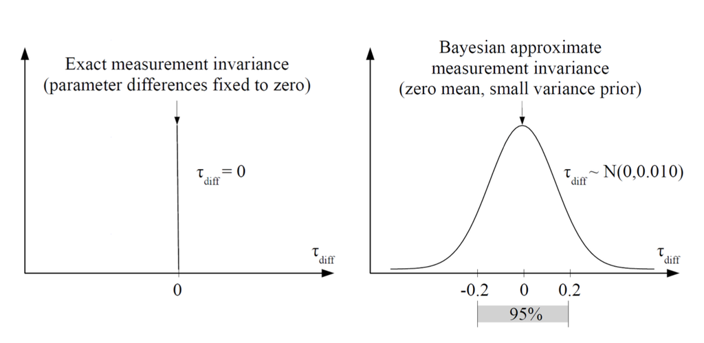

**Example**

Difference $\tau_1-\tau_2$

$V(\tau_1-\tau_2)=V(\tau_1)+V(\tau_2)-2Cov(\tau_1,\tau_2)$

- The smaller the prior variance, the more the results will be closer to exact MI
- The larger the prior variance, the more the results will reflect a configural model

“(…) Bayesian approaches allow researchers to incorporate background knowledge into their analyses instead of (…) ignoring the lessons of previous studies. (…) [S]tatistical methods based on the frequentist (classical) paradigm (i.e., the default approach in most software) often involve testing the null hypothesis. In plain terms, the null hypothesis states that “nothing is going on.” This hypothesis might be a bad starting point because, based on previous research, it is almost always expected that “something is going on”. Schoot et al. (2014); emphases by D. Seddig

- Background knowledge: parameters may not be invariant
- Expectation (hypothesis): parameter differences are not (exactly) zero

## Procedure

- All parameters in a statistical model are given a joint probability distribution (prior and data distributions)
- Available knowledge about parameters in a statistical model is captured via prior distributions
- Information about the parameters in the data is captured by the likelihood function
- Both are combined using estimation techniques (e.g., Gibbs Sampler, MH Sampler) in the form of the posterior distribution
- Posterior distribution: updated knowledge, balancing prior knowledge with observed data

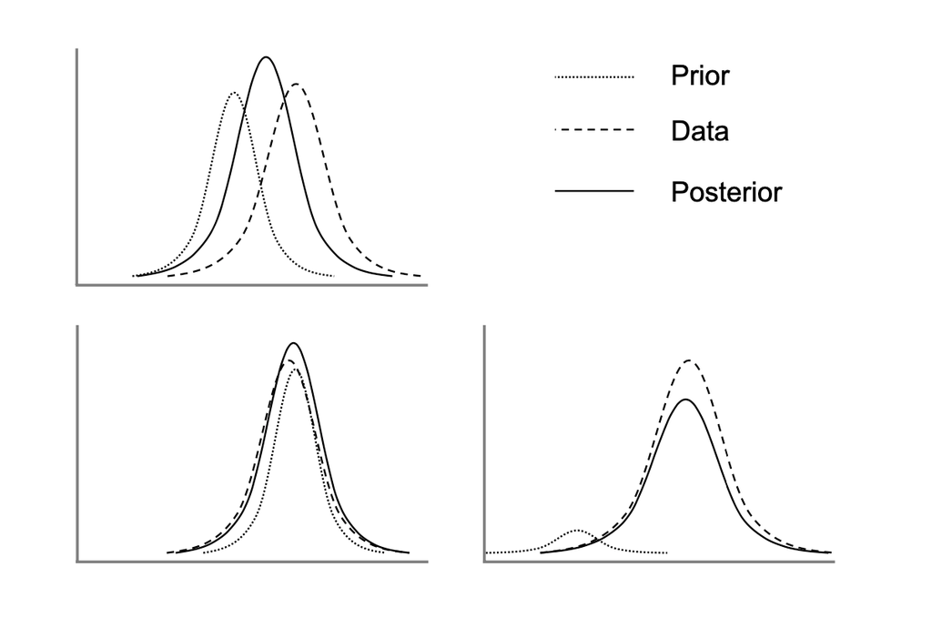

Estimation: Markov chain Monte Carlo (MCMC) sampling - see Gelfand and Smith (1990)

- Iterative sampling from the posterior
- Monte Carlo: random simulation process
- Markov chain: sampling a new value from the posterior distribution, given the previous value

Convergence monitoring

- Potential scale reduction factor (PSR, Gelman & Rubin, 1992):
  - ratio of total variation across chains/variation within chains
  - values close to 1 indicate convergence
- Graphical (e.g., trace plots)

**Model fit and comparison** - see Gelman, Meng, and Stern (1996)

- Bayesian or posterior predictive p-value $(p_B~or~ppp)$

$p_B=Pr(D(y^{rep})\geq D(y)|y)$

- proportion of replicated data sets with a discrepancy measure (e.g., $\chi^2$) exceeding the discrepancy measure of the original data given the model
- acceptable fit: $p_B>.05$
- Deviance Information Criterion (Spiegelhalter et al., 2002)

## Bayes MI - Universalism

Before we can start the analysis, we must first take a sample, otherwise the calculations would take too long.

```r
ESS07_sample <- ESS07 %>%
  sample_n(500)
```

### Model for whole population

```r
universalism_fit_bayes <- bcfa(
    model = "Universalism =~ ipeqopt + ipudrst + impenv",
    data = ESS07_sample,
    # not working
    # estimator = "MLR",
    # missing = "fiml.x",
    n.chains=2,
    burnin=5000,
    sample=5000,
    inits="simple"
    )
```

```
Computing posterior predictives...
```

```r
fitMeasures(universalism_fit_bayes)
```

```
      npar       logl        ppp        bic        dic      p_dic       waic
     6.000  -2179.736      0.484   4396.748   4371.641      6.084   4375.608
    p_waic    se_waic      looic      p_loo     se_loo margloglik
     9.882     83.105   4375.630      9.893     83.109  -2199.856
```

```r
summary(
  object = universalism_fit_bayes,
  fit.measures = T,
  standardized = T
  # rsquare = T
  )
```

```
blavaan (0.4-6) results of 5000 samples after 5000 adapt/burnin iterations

  Number of observations                           500

  Statistic                                 MargLogLik         PPP
  Value                                      -2199.856       0.484

Latent Variables:
                   Estimate  Post.SD pi.lower pi.upper   Std.lv  Std.all
  Universalism =~
    ipeqopt           1.000                               0.692    0.642
    ipudrst           0.877    0.165    0.585    1.236    0.607    0.560
    impenv            0.792    0.144    0.533    1.094    0.548    0.496
     Rhat    Prior


    1.000    normal(0,10)
    1.000    normal(0,10)

Variances:
                   Estimate  Post.SD pi.lower pi.upper   Std.lv  Std.all
   .ipeqopt           0.685    0.100    0.474    0.867    0.685    0.588
   .ipudrst           0.807    0.084    0.642    0.972    0.807    0.686
   .impenv            0.921    0.080    0.768    1.081    0.921    0.754
    Universalism      0.479    0.108    0.296    0.722    1.000    1.000
     Rhat    Prior
    1.000 gamma(1,.5)[sd]
    1.000 gamma(1,.5)[sd]
    1.000 gamma(1,.5)[sd]
    1.000 gamma(1,.5)[sd]
```

### Measurement for each group

```r
universalism_fit_bayes_countries <- ESS07_countries %>%
  map(~ bcfa(
    model = "Universalism =~ ipeqopt + ipudrst + impenv",
    data = .,
    # not working
    # estimator = "MLR",
    # missing = "fiml.x",
    n.chains=2,
    burnin=5000,
    sample=5000,
    inits="simple"
    ))
```

```
Computing posterior predictives...


Computing posterior predictives...


Computing posterior predictives...
```

```r
universalism_fit_bayes_countries %>%
  map(~ fitMeasures(.x))
```

```
$CZ
      npar       logl        ppp        bic        dic      p_dic       waic
     6.000  -5999.487      0.513  12042.406  12010.667      5.846  12012.815
    p_waic    se_waic      looic      p_loo     se_loo margloglik
     7.950    119.862  12012.821      7.952    119.862  -6022.958

$DE
      npar       logl        ppp        bic        dic      p_dic       waic
     6.000 -10537.925      0.502  21123.189  21087.806      5.978  21092.405
    p_waic    se_waic      looic      p_loo     se_loo margloglik
    10.537    201.272  21092.415     10.542    201.272 -10563.545

$GB
      npar       logl        ppp        bic        dic      p_dic       waic
     6.000  -7712.404      0.492  15469.711  15436.672      5.932  15439.193
    p_waic    se_waic      looic      p_loo     se_loo margloglik
     8.418    138.843  15439.198      8.421    138.844  -7736.050
```

```r
universalism_fit_bayes_countries %>%
  map(~ summary(
    object = .x,
    fit.measures = T,
    standardized = T
    # rsquare = T
  ))
```

```
blavaan (0.4-6) results of 5000 samples after 5000 adapt/burnin iterations

  Number of observations                          1393

  Statistic                                 MargLogLik         PPP
  Value                                      -6022.958       0.513

Latent Variables:
                   Estimate  Post.SD pi.lower pi.upper   Std.lv  Std.all
  Universalism =~
    ipeqopt           1.000                               0.599    0.564
    ipudrst           0.961    0.090    0.799    1.152    0.576    0.526
    impenv            1.106    0.113    0.908    1.352    0.662    0.628
     Rhat    Prior


    1.000    normal(0,10)
    1.000    normal(0,10)

Variances:
                   Estimate  Post.SD pi.lower pi.upper   Std.lv  Std.all
   .ipeqopt           0.769    0.046    0.681    0.859    0.769    0.682
   .ipudrst           0.866    0.046    0.777    0.957    0.866    0.723
   .impenv            0.671    0.050    0.569    0.766    0.671    0.605
    Universalism      0.358    0.047    0.272    0.454    1.000    1.000
     Rhat    Prior
    1.000 gamma(1,.5)[sd]
    1.000 gamma(1,.5)[sd]
    1.000 gamma(1,.5)[sd]
    1.000 gamma(1,.5)[sd]

blavaan (0.4-6) results of 5000 samples after 5000 adapt/burnin iterations

  Number of observations                          2671

  Statistic                                 MargLogLik         PPP
  Value                                     -10563.545       0.502

Latent Variables:
                   Estimate  Post.SD pi.lower pi.upper   Std.lv  Std.all
```

[output cut: 37 more lines]

```

    1.000    normal(0,10)
    1.000    normal(0,10)

Variances:
                   Estimate  Post.SD pi.lower pi.upper   Std.lv  Std.all
   .ipeqopt           0.809    0.046    0.721    0.901    0.809    0.725
   .ipudrst           0.603    0.065    0.463    0.721    0.603    0.536
   .impenv            0.992    0.040    0.916    1.072    0.992    0.844
    Universalism      0.307    0.045    0.223    0.399    1.000    1.000
     Rhat    Prior
    1.000 gamma(1,.5)[sd]
    1.000 gamma(1,.5)[sd]
    1.001 gamma(1,.5)[sd]
    1.000 gamma(1,.5)[sd]
```

```
$CZ
                     Estimate    Post.SD   pi.lower   pi.upper     Std.lv
 "   ipeqopt       " "   1.000" ""         "        " "        " "   0.599"
 "   ipudrst       " "   0.961" "   0.090" "   0.799" "   1.152" "   0.576"
 "   impenv        " "   1.106" "   0.113" "   0.908" "   1.352" "   0.662"
 "  .ipeqopt       " "   0.769" "   0.046" "   0.681" "   0.859" "   0.769"
 "  .ipudrst       " "   0.866" "   0.046" "   0.777" "   0.957" "   0.866"
 "  .impenv        " "   0.671" "   0.050" "   0.569" "   0.766" "   0.671"
 "   Universalism  " "   0.358" "   0.047" "   0.272" "   0.454" "   1.000"
  Std.all       Rhat      Prior
 "   0.564" "        " "               "
 "   0.526" "   1.000" "   normal(0,10)"
 "   0.628" "   1.000" "   normal(0,10)"
 "   0.682" "   1.000" "gamma(1,.5)[sd]"
 "   0.723" "   1.000" "gamma(1,.5)[sd]"
 "   0.605" "   1.000" "gamma(1,.5)[sd]"
 "   1.000" "   1.000" "gamma(1,.5)[sd]"

$DE
                     Estimate    Post.SD   pi.lower   pi.upper     Std.lv
 "   ipeqopt       " "   1.000" ""         "        " "        " "   0.487"
 "   ipudrst       " "   0.982" "   0.092" "   0.815" "   1.179" "   0.479"
 "   impenv        " "   0.930" "   0.085" "   0.773" "   1.108" "   0.453"
 "  .ipeqopt       " "   0.679" "   0.029" "   0.621" "   0.737" "   0.679"
 "  .ipudrst       " "   0.548" "   0.027" "   0.493" "   0.601" "   0.548"
 "  .impenv        " "   0.705" "   0.028" "   0.651" "   0.760" "   0.705"
 "   Universalism  " "   0.237" "   0.028" "   0.185" "   0.297" "   1.000"
  Std.all       Rhat      Prior
 "   0.509" "        " "               "
 "   0.543" "   1.000" "   normal(0,10)"
 "   0.475" "   1.000" "   normal(0,10)"
 "   0.741" "   1.000" "gamma(1,.5)[sd]"
 "   0.705" "   1.000" "gamma(1,.5)[sd]"
 "   0.775" "   1.000" "gamma(1,.5)[sd]"
 "   1.000" "   1.000" "gamma(1,.5)[sd]"

$GB
                     Estimate    Post.SD   pi.lower   pi.upper     Std.lv
 "   ipeqopt       " "   1.000" ""         "        " "        " "   0.554"
 "   ipudrst       " "   1.303" "   0.162" "   1.028" "   1.668" "   0.722"
 "   impenv        " "   0.773" "   0.077" "   0.630" "   0.929" "   0.428"
 "  .ipeqopt       " "   0.809" "   0.046" "   0.721" "   0.901" "   0.809"
 "  .ipudrst       " "   0.603" "   0.065" "   0.463" "   0.721" "   0.603"
 "  .impenv        " "   0.992" "   0.040" "   0.916" "   1.072" "   0.992"
 "   Universalism  " "   0.307" "   0.045" "   0.223" "   0.399" "   1.000"
  Std.all       Rhat      Prior
 "   0.524" "        " "               "
 "   0.681" "   1.000" "   normal(0,10)"
 "   0.395" "   1.000" "   normal(0,10)"
 "   0.725" "   1.000" "gamma(1,.5)[sd]"
 "   0.536" "   1.000" "gamma(1,.5)[sd]"
 "   0.844" "   1.001" "gamma(1,.5)[sd]"
 "   1.000" "   1.000" "gamma(1,.5)[sd]"
```

### Configural model

```r
universalism_fit_bayes_config <- bcfa(
    model = "Universalism =~ ipeqopt + ipudrst + impenv",
    data = ESS07_sample,
    # not working
    # estimator = "MLR",
    # missing = "fiml.x",
    group="country",
    n.chains=2,
    burnin=5000,
    sample=5000,
    inits="simple"
    )
```

```
Computing posterior predictives...
```

```r
fitMeasures(universalism_fit_bayes_config)
```

```
      npar       logl        ppp        bic        dic      p_dic       waic
    27.000  -2133.742      0.375   4435.117   4277.562      5.038   4311.037
    p_waic    se_waic      looic      p_loo     se_loo margloglik
    36.749     84.228   4311.228     36.845     84.257  -2228.902
```

```r
summary(
  object = universalism_fit_bayes_config,
  fit.measures = T,
  standardized = T
  # rsquare = T
  )
```

```
blavaan (0.4-6) results of 5000 samples after 5000 adapt/burnin iterations

  Number of observations per group
  DE                                               239
  GB                                               129
  CZ                                               132

  Statistic                                 MargLogLik         PPP
  Value                                      -2228.902       0.375


Group 1 []:

Latent Variables:
                   Estimate  Post.SD pi.lower pi.upper   Std.lv  Std.all
  Universalism =~
    ipeqopt           1.000                               0.394    0.421
    ipudrst           1.549    1.840    0.226    6.728    0.611    0.638
    impenv            1.572    1.959    0.230    7.057    0.620    0.589
     Rhat    Prior


    1.001    normal(0,10)
    1.001    normal(0,10)

Intercepts:
                   Estimate  Post.SD pi.lower pi.upper   Std.lv  Std.all
   .ipeqopt           5.160    0.060    5.043    5.279    5.160    5.505
   .ipudrst           4.967    0.054    4.859    5.073    4.967    5.192
   .impenv            5.012    0.060    4.893    5.133    5.012    4.759
    Universalism      0.000                               0.000    0.000
     Rhat    Prior
    1.000    normal(0,32)
    1.000    normal(0,32)
    1.000    normal(0,32)


Variances:
                   Estimate  Post.SD pi.lower pi.upper   Std.lv  Std.all
   .ipeqopt           0.723    0.156    0.315    0.962    0.723    0.823
```

[output cut: 71 more lines]

```
    1.000    normal(0,32)
    1.000    normal(0,32)


Variances:
                   Estimate  Post.SD pi.lower pi.upper   Std.lv  Std.all
   .ipeqopt           0.743    0.284    0.063    1.235    0.743    0.554
   .ipudrst           1.338    0.204    0.970    1.772    1.338    0.814
   .impenv            0.771    0.299    0.031    1.264    0.771    0.497
    Universalism      0.597    0.303    0.146    1.324    1.000    1.000
     Rhat    Prior
    1.000 gamma(1,.5)[sd]
    1.000 gamma(1,.5)[sd]
    1.000 gamma(1,.5)[sd]
    1.000 gamma(1,.5)[sd]
```

### Metric model

```r
universalism_fit_bayes_metric <- bcfa(
    model = "Universalism =~ ipeqopt + ipudrst + impenv",
    data = ESS07_sample,
    # not working
    # estimator = "MLR",
    # missing = "fiml.x",
    group="country",
    group.equal = c("loadings"),
    wiggle = c("loadings"),
    wiggle.sd = 0.05,
    n.chains = 2,
    burnin = 5000,
    sample = 5000,
    inits = "simple"
    )
```

```
Computing posterior predictives...
```

```r
fitMeasures(universalism_fit_bayes_metric)
```

```
      npar       logl        ppp        bic        dic      p_dic       waic
    23.000  -2122.638      0.531   4388.073   4291.407     23.066   4301.529
    p_waic    se_waic      looic      p_loo     se_loo margloglik
    31.828     84.785   4301.752     31.940     84.827  -2212.274
```

```r
summary(
  object = universalism_fit_bayes_metric,
  fit.measures = T,
  standardized = T
  # rsquare = T
  )
```

```
blavaan (0.4-6) results of 5000 samples after 5000 adapt/burnin iterations

  Number of observations per group
  DE                                               239
  GB                                               129
  CZ                                               132

  Statistic                                 MargLogLik         PPP
  Value                                      -2212.274       0.531


Group 1 []:

Latent Variables:
                   Estimate  Post.SD pi.lower pi.upper   Std.lv  Std.all
  Universalism =~
    ipeqopt           1.000                               0.455    0.485
    ipudrst (.p2.)    0.816    0.192    0.469    1.222    0.371    0.438
    impenv  (.p3.)    0.784    0.176    0.450    1.145    0.357    0.375
     Rhat    Prior


    1.000               normal(0,10)
    1.001               normal(0,10)

Intercepts:
                   Estimate  Post.SD pi.lower pi.upper   Std.lv  Std.all
   .ipeqopt           5.160    0.060    5.041    5.279    5.160    5.498
   .ipudrst           4.967    0.056    4.858    5.076    4.967    5.856
   .impenv            5.013    0.062    4.892    5.134    5.013    5.271
    Universalism      0.000                               0.000    0.000
     Rhat    Prior
    1.000               normal(0,32)
    1.000               normal(0,32)
    1.000               normal(0,32)


Variances:
                   Estimate  Post.SD pi.lower pi.upper   Std.lv  Std.all
   .ipeqopt           0.673    0.098    0.472    0.860    0.673    0.765
```

[output cut: 71 more lines]

```
    1.000               normal(0,32)
    1.000               normal(0,32)


Variances:
                   Estimate  Post.SD pi.lower pi.upper   Std.lv  Std.all
   .ipeqopt           0.680    0.206    0.215    1.072    0.680    0.504
   .ipudrst           1.257    0.201    0.902    1.702    1.257    0.744
   .impenv            0.938    0.160    0.641    1.273    0.938    0.691
    Universalism      0.668    0.219    0.329    1.205    1.000    1.000
     Rhat    Prior
    1.000            gamma(1,.5)[sd]
    1.000            gamma(1,.5)[sd]
    1.000            gamma(1,.5)[sd]
    1.000            gamma(1,.5)[sd]
```

### Scalar model

```r
universalism_fit_bayes_scalar <- bcfa(
    model = "Universalism =~ ipeqopt + ipudrst + impenv",
    data = ESS07_sample,
    # not working
    # estimator = "MLR",
    # missing = "fiml.x",
    group="country",
    group.equal = c("loadings", "intercepts"),
    wiggle = c("loadings", "intercepts"),
    wiggle.sd = 0.05,
    n.chains = 2,
    burnin = 5000,
    sample = 5000,
    inits = "simple"
    )
```

```
Computing posterior predictives...
```

```r
fitMeasures(universalism_fit_bayes_scalar)
```

```
      npar       logl        ppp        bic        dic      p_dic       waic
    19.000  -2125.050      0.466   4368.063   4289.095     19.498   4299.257
    p_waic    se_waic      looic      p_loo     se_loo margloglik
    28.438     84.902   4299.418     28.519     84.926  -2190.769
```

```r
summary(
  object = universalism_fit_bayes_scalar,
  fit.measures = T,
  standardized = T
  # rsquare = T
  )
```

```
blavaan (0.4-6) results of 5000 samples after 5000 adapt/burnin iterations

  Number of observations per group
  DE                                               239
  GB                                               129
  CZ                                               132

  Statistic                                 MargLogLik         PPP
  Value                                      -2190.769       0.466


Group 1 []:

Latent Variables:
                   Estimate  Post.SD pi.lower pi.upper   Std.lv  Std.all
  Universalism =~
    ipeqopt           1.000                               0.418    0.446
    ipudrst (.p2.)    0.971    0.170    0.675    1.346    0.406    0.478
    impenv  (.p3.)    0.803    0.128    0.567    1.067    0.336    0.354
     Rhat    Prior


    1.000               normal(0,10)
    1.000               normal(0,10)

Intercepts:
                   Estimate  Post.SD pi.lower pi.upper   Std.lv  Std.all
   .ipeqopt (.p8.)    5.172    0.056    5.063    5.283    5.172    5.517
   .ipudrst (.p9.)    4.951    0.053    4.846    5.055    4.951    5.831
   .impenv  (.10.)    5.011    0.055    4.903    5.120    5.011    5.291
    Unvrsls           0.000                               0.000    0.000
     Rhat    Prior
    1.001               normal(0,32)
    1.000               normal(0,32)
    1.000               normal(0,32)


Variances:
                   Estimate  Post.SD pi.lower pi.upper   Std.lv  Std.all
   .ipeqopt           0.704    0.085    0.548    0.879    0.704    0.801
```

[output cut: 71 more lines]

```
    1.001     normal(nu[1,2,1],0.05)
    1.000     normal(nu[1,3,1],0.05)
    1.000               normal(0,10)

Variances:
                   Estimate  Post.SD pi.lower pi.upper   Std.lv  Std.all
   .ipeqopt           0.764    0.162    0.456    1.097    0.764    0.574
   .ipudrst           1.209    0.201    0.852    1.638    1.209    0.692
   .impenv            0.961    0.151    0.693    1.290    0.961    0.725
    Universalism      0.567    0.160    0.298    0.923    1.000    1.000
     Rhat    Prior
    1.000            gamma(1,.5)[sd]
    1.000            gamma(1,.5)[sd]
    1.000            gamma(1,.5)[sd]
    1.000            gamma(1,.5)[sd]
```

# References

Beauducel, Andre, and Philipp Yorck Herzberg. 2006. “On the Performance of Maximum Likelihood Versus Means and Variance Adjusted Weighted Least Squares Estimation in CFA.” *Structural Equation Modeling: A Multidisciplinary Journal* 13 (2): 186–203. https://doi.org/10.1207/s15328007sem1302_2.

Finney, Sara J., and Christine DiStefano. 2013. “Nonnormal and Categorical Data in Structural Equation Modeling.” In *Structural Equation Modeling: A Second Course*, edited by Gregory R. Hancock and Ralph O. Mueller, 2nd ed, 439–92. Quantitative Methods in Education and the Behavioral Sciences. Charlotte, NC: Information Age Publishing, Inc.

Gelfand, Alan E., and Adrian F. M. Smith. 1990. “Sampling-Based Approaches to Calculating Marginal Densities.” *Journal of the American Statistical Association* 85 (410): 398–409. https://doi.org/10.1080/01621459.1990.10476213.

Gelman, Andrew, Xiao-Li Meng, and Hal Stern. 1996. “POSTERIOR PREDICTIVE ASSESSMENT OF MODEL FITNESS VIA REALIZED DISCREPANCIES.” *Statistica Sinica* 6 (4): 733–60. http://www.jstor.org/stable/24306036.

Kim, Eun Sook, and Myeongsun Yoon. 2011. “Testing Measurement Invariance: A Comparison of Multiple-Group Categorical CFA and IRT.” *Structural Equation Modeling: A Multidisciplinary Journal* 18 (2): 212–28. https://doi.org/10.1080/10705511.2011.557337.

Li, Cheng-Hsien. 2016. “Confirmatory Factor Analysis with Ordinal Data: Comparing Robust Maximum Likelihood and Diagonally Weighted Least Squares.” *Behavior Research Methods* 48 (3): 936–49. https://doi.org/10.3758/s13428-015-0619-7.

Muthén, Bengt, and Tihomir Asparouhov. 2012. “Bayesian Structural Equation Modeling: A More Flexible Representation of Substantive Theory.” *Psychological Methods* 17 (3): 313–35. https://doi.org/10.1037/a0026802.

Rhemtulla, Mijke, Patricia É. Brosseau-Liard, and Victoria Savalei. 2012. “When Can Categorical Variables Be Treated as Continuous? A Comparison of Robust Continuous and Categorical SEM Estimation Methods Under Suboptimal Conditions.” *Psychological Methods* 17 (3): 354–73. https://doi.org/10.1037/a0029315.

Satorra, Albert, and Peter M. Bentler. 1990. “Model Conditions for Asymptotic Robustness in the Analysis of Linear Relations.” *Computational Statistics & Data Analysis* 10 (3): 235–49. https://doi.org/10.1016/0167-9473(90)90004-2.

Schoot, Rens van de, David Kaplan, Jaap Denissen, Jens B. Asendorpf, Franz J. Neyer, and Marcel A. G. van Aken. 2014. “A Gentle Introduction to Bayesian Analysis: Applications to Developmental Research.” *Child Development* 85 (3): 842–60. https://doi.org/10.1111/cdev.12169.

Schoot, Rens van de, Anouck Kluytmans, Lars Tummers, Peter Lugtig, Joop Hox, and Bengt Muthén. 2013. “Facing Off with Scylla and Charybdis: A Comparison of Scalar, Partial, and the Novel Possibility of Approximate Measurement Invariance.” *Frontiers in Psychology* 4. https://doi.org/10.3389/fpsyg.2013.00770.

Seddig, Daniel, and Heinz Leitgöb. 2018. “Approximate Measurement Invariance and Longitudinal Confirmatory Factor Analysis: Concept and Application with Panel Data.” *Survey Research Methods* Vol 12 (April): 29–41 Pages. https://doi.org/10.18148/SRM/2018.V12I1.7210.

Svetina, Dubravka, Leslie Rutkowski, and David Rutkowski. 2020. “Multiple-Group Invariance with Categorical Outcomes Using Updated Guidelines: An Illustration Using M *Plus* and the Lavaan/semTools Packages.” *Structural Equation Modeling: A Multidisciplinary Journal* 27 (1): 111–30. https://doi.org/10.1080/10705511.2019.1602776.